# 1.amt_conv

Dennis Kim

2022-10-06

# Objective

To explore the structure of the bear data set. To do this, I will:

1. Generate used and available locations of the bear through amt framework.
2. Extract habitat covariate from habitat layer.
3. Create a sf polygon per each step length representing a buffer
4. Calculate the points that fall within each buffer and count the number of locations that revisited
5. Similar to Uli’s paper, the locations that are visited to each buffer will count as 0, otherwise +1
6. Include TSLV values per each observations throughtout the time and save them in the column of the data
7. Fit SSF model with a TSLV predictor

## Tracking data

Read in the gps data

```r
# Location data of the bear
bear <- read.csv(here::here("data", "GF1143_raw.csv"))

# change the time format of the data
bear$datetime <- as.POSIXct(bear$datetime, format =  "%Y-%m-%d %H:%M")

# summary of the data
summary(bear)
```

```
       t                x                y              datetime
 Min.   :   3.0   Min.   :532666   Min.   :7598348   Min.   :2005-05-24 00:18:00.00
 1st Qu.: 244.5   1st Qu.:544414   1st Qu.:7618498   1st Qu.:2005-07-03 06:18:00.00
 Median : 486.5   Median :552421   Median :7629107   Median :2005-08-12 14:18:00.00
 Mean   :1079.4   Mean   :550952   Mean   :7627208   Mean   :2005-11-19 09:00:38.38
 3rd Qu.:2218.2   3rd Qu.:556623   3rd Qu.:7637886   3rd Qu.:2006-05-28 05:18:00.00
 Max.   :2469.0   Max.   :572915   Max.   :7646027   Max.   :2006-07-09 00:18:00.00
```

Plot the data

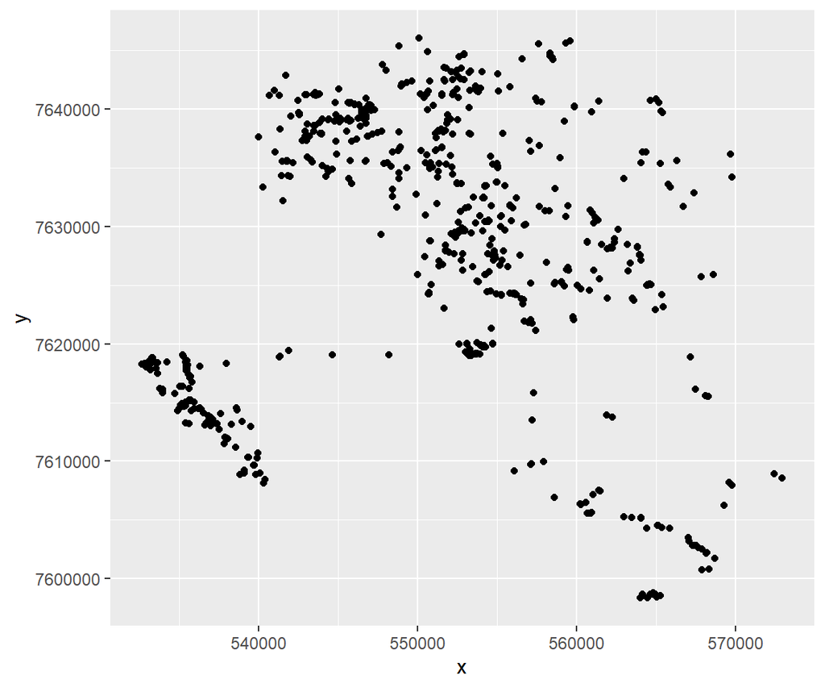

```r
ggplot(bear, aes(x = x, y = y))+
  geom_point()
```

## Prepare environmental data

Add environmental covariate (berry)

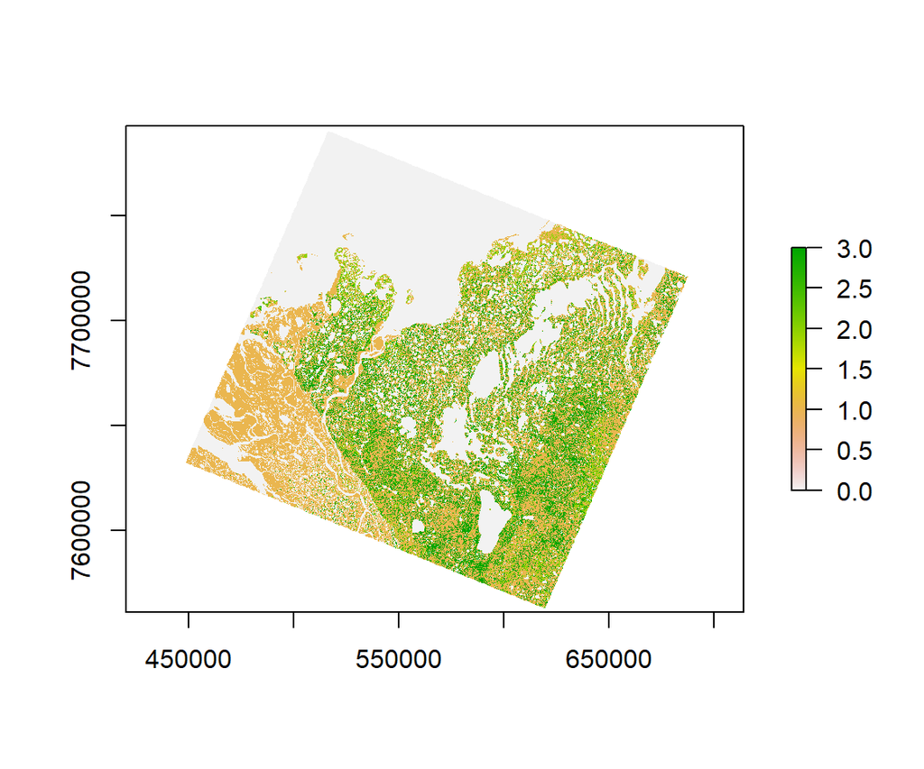

```r
# call the berries layer
berry <- raster(here("data/berries/berries.tif"))

# plot the layer
plot(berry)
```

```r
# crs of the layer
crs(berry)
```

```
Coordinate Reference System:
Deprecated Proj.4 representation:
 +proj=utm +zone=8 +datum=NAD83 +units=m +no_defs
WKT2 2019 representation:
PROJCRS["NAD_1983_UTM_Zone_8N",
    BASEGEOGCRS["NAD83",
        DATUM["North American Datum 1983",
            ELLIPSOID["GRS 1980",6378137,298.257222101004,
                LENGTHUNIT["metre",1]]],
        PRIMEM["Greenwich",0,
            ANGLEUNIT["degree",0.0174532925199433]],
        ID["EPSG",4269]],
    CONVERSION["Transverse Mercator",
        METHOD["Transverse Mercator",
            ID["EPSG",9807]],
        PARAMETER["Latitude of natural origin",0,
            ANGLEUNIT["degree",0.0174532925199433],
            ID["EPSG",8801]],
        PARAMETER["Longitude of natural origin",-135,
            ANGLEUNIT["degree",0.0174532925199433],
            ID["EPSG",8802]],
        PARAMETER["Scale factor at natural origin",0.9996,
            SCALEUNIT["unity",1],
            ID["EPSG",8805]],
        PARAMETER["False easting",500000,
            LENGTHUNIT["metre",1],
            ID["EPSG",8806]],
        PARAMETER["False northing",0,
            LENGTHUNIT["metre",1],
            ID["EPSG",8807]]],
    CS[Cartesian,2],
        AXIS["easting",east,
            ORDER[1],
            LENGTHUNIT["metre",1]],
        AXIS["northing",north,
            ORDER[2],
            LENGTHUNIT["metre",1]],
    ID["EPSG",26908]]
```

## amt conversion

Add a track class to the data and summarize the data

```r
# make tracks
trk.bear <- amt::make_track(bear, .x=x, .y=y, .t=datetime, crs=CRS("+init=epsg:26908"))
summary(trk.bear)
```

```
       x_               y_                t_
 Min.   :532666   Min.   :7598348   Min.   :2005-05-24 00:18:00.00
 1st Qu.:544414   1st Qu.:7618498   1st Qu.:2005-07-03 06:18:00.00
 Median :552421   Median :7629107   Median :2005-08-12 14:18:00.00
 Mean   :550952   Mean   :7627208   Mean   :2005-11-19 09:00:38.38
 3rd Qu.:556623   3rd Qu.:7637886   3rd Qu.:2006-05-28 05:18:00.00
 Max.   :572915   Max.   :7646027   Max.   :2006-07-09 00:18:00.00
```

Summarize the sampling rates of the bear

```r
# 4 hour sampling seems reasonable - no need to resample - since it is already resampled
summarize_sampling_rate(trk.bear)
```

```
# A tibble: 1 × 9
    min    q1 median  mean    q3   max    sd     n unit
  <dbl> <dbl>  <dbl> <dbl> <dbl> <dbl> <dbl> <int> <chr>
1     4     4      4  12.5     4  5944  212.   787 hour
```

change the track point to step 1. Resample track and filter bursts 2. Convert track to steps 3. Create random steps 4. Extract covariate values

```r
# follow the above approach
ssfdat.bear <-
  trk.bear %>% track_resample(rate = hours(4), tolerance = minutes(30)) %>%
  steps_by_burst() %>%
  random_steps(n_control = 5) %>%
  extract_covariates(berry) %>%
  filter(!is.na(ta_))

# summary of the ssf data
summary(ssfdat.bear)
```

```
     burst_            x1_              x2_              y1_               y2_               sl_               ta_
 Min.   :  1.00   Min.   :532666   Min.   :528949   Min.   :7598348   Min.   :7594550   Min.   :    0.0   Min.   :-3.14077
 1st Qu.: 31.00   1st Qu.:544874   1st Qu.:544620   1st Qu.:7618388   1st Qu.:7618369   1st Qu.:  127.5   1st Qu.:-1.27893
 Median : 73.00   Median :552464   Median :552424   Median :7628681   Median :7628474   Median :  498.9   Median : 0.04311
 Mean   : 65.52   Mean   :551092   Mean   :551091   Mean   :7626903   Mean   :7626891   Mean   : 1033.0   Mean   : 0.01965
 3rd Qu.: 97.00   3rd Qu.:556984   3rd Qu.:556990   3rd Qu.:7637691   3rd Qu.:7637636   3rd Qu.: 1375.0   3rd Qu.: 1.29798
 Max.   :132.00   Max.   :572427   Max.   :574450   Max.   :7646027   Max.   :7649877   Max.   :14524.3   Max.   : 3.13794
      t1_                             t2_                            dt_              step_id_       case_            berries
 Min.   :2005-05-24 00:18:00.0   Min.   :2005-05-24 04:18:00.0   Length:3814       Min.   :  1.0   Mode :logical   Min.   :0.000
 1st Qu.:2005-07-02 16:18:00.0   1st Qu.:2005-07-02 20:18:00.0   Class :difftime   1st Qu.:165.0   FALSE:3280      1st Qu.:1.000
 Median :2005-08-13 20:18:00.0   Median :2005-08-14 00:18:00.0   Mode  :numeric    Median :330.0   TRUE :534       Median :1.000
 Mean   :2005-11-20 01:09:15.2   Mean   :2005-11-20 05:09:15.2                     Mean   :328.7                   Mean   :1.433
 3rd Qu.:2006-05-27 16:18:00.0   3rd Qu.:2006-05-27 20:18:00.0                     3rd Qu.:492.0                   3rd Qu.:2.000
 Max.   :2006-07-08 20:18:00.0   Max.   :2006-07-09 00:18:00.0                     Max.   :656.0                   Max.   :3.000
```

Check the reasonable buffer distance for each step length - I will pick 1000m as a buffer distance from the step lengths

```r
ssfdat.bear %>% filter(case_ == "TRUE") %>% dplyr::select(sl_) %>% summary()
```

```
      sl_
 Min.   :   4.197
 1st Qu.: 123.622
 Median : 491.674
 Mean   :1051.328
 3rd Qu.:1591.749
 Max.   :7646.065
```

## Create observation points

select randomized and used locations of the tracks from the ssfdat.bear

```r
# select random locations that matched with observed step lengths
obs <- ssfdat.bear %>% filter(case_ == TRUE)
ran <- ssfdat.bear %>% filter(case_ == FALSE)

# select observed locations
obs.loc <- obs %>% dplyr::select(x1_, y1_)
colnames(obs.loc) <- c("x", "y")
obs.loc.sf <- st_as_sf(obs.loc, coords = c("x", "y"), crs = "+proj=utm +zone=8 +datum=NAD83 +units=m +no_defs")
obs.loc.sf %>% head()
```

```
Simple feature collection with 6 features and 0 fields
Geometry type: POINT
Dimension:     XY
Bounding box:  xmin: 564003.4 ymin: 7598348 xmax: 564965.4 ymax: 7598696
CRS:           +proj=utm +zone=8 +datum=NAD83 +units=m +no_defs
# A tibble: 6 × 1
            geometry
         <POINT [m]>
1 (564948.3 7598663)
2 (564003.4 7598348)
3 (564140.5 7598586)
4 (564421.8 7598391)
5 (564121.5 7598696)
6 (564965.4 7598496)
```

```r
## mapview
mapview(obs.loc.sf, cex = 3, alpha = 0.5, popup = NULL)
```

[interactive chart not shown]

```r
# select random locations
ran.loc <- ran %>% dplyr::select(x2_, y2_)
colnames(ran.loc) <- c("x", "y")
ran.loc.sf <- st_as_sf(ran.loc, coords = c("x", "y"), crs = "+proj=utm +zone=8 +datum=NAD83 +units=m +no_defs")
ran.loc.sf %>% head()
```

```
Simple feature collection with 6 features and 0 fields
Geometry type: POINT
Dimension:     XY
Bounding box:  xmin: 561735.6 ymin: 7598019 xmax: 564974.3 ymax: 7598663
CRS:           +proj=utm +zone=8 +datum=NAD83 +units=m +no_defs
# A tibble: 6 × 1
            geometry
         <POINT [m]>
1 (564386.1 7598462)
2 (561735.6 7598101)
3 (564974.3 7598019)
4   (564634 7598600)
5 (564838.3 7598436)
6 (564945.9 7598663)
```

```r
## mapview
mapview(ran.loc.sf, cex = 3, alpha = 0.5, popup = NULL)
```

[interactive chart not shown]

## create a square grid

we will first create a grid which the extent equals to the bounding box of the selected points

```r
# create 1000m x 1000m grid cell in the map
area_bear_visit_grid = st_make_grid(obs.loc.sf, c(1000, 1000), what = "polygons", square = TRUE)
area_bear_visit_grid
```

```
Geometry set for 1920 features
Geometry type: POLYGON
Dimension:     XY
Bounding box:  xmin: 532665.7 ymin: 7598348 xmax: 572665.7 ymax: 7646348
CRS:           +proj=utm +zone=8 +datum=NAD83 +units=m +no_defs
First 5 geometries:
```

```
POLYGON ((532665.7 7598348, 533665.7 7598348, 5...
```

```
POLYGON ((533665.7 7598348, 534665.7 7598348, 5...
```

```
POLYGON ((534665.7 7598348, 535665.7 7598348, 5...
```

```
POLYGON ((535665.7 7598348, 536665.7 7598348, 5...
```

```
POLYGON ((536665.7 7598348, 537665.7 7598348, 5...
```

```r
# To sf and add grid ID
fishnet_grid_sf = st_sf(area_bear_visit_grid) %>%
  # add grid ID
  mutate(grid_id = 1:length(lengths(area_bear_visit_grid)))

# create a grid sf for observed and random
fishnet_grid_sf_obs <- fishnet_grid_sf
fishnet_grid_sf_ran <- fishnet_grid_sf
```

## Time Since Last Vitist (TSLV)

Follow Uli’s approach: Their definition of TSLV is short and sweet (see equation 4 in that paper) - basically, it’s 0 if the point in question is within some distance δ (this value could be similar to the value you used for your buffer) of the previous point, and otherwise it’s (previous TSLV + 1). So they define it iteratively, starting at the first point and iteratively updating TSLV with each time step.

### Observed Locations

Then count the number of revisitations from observed locations

```r
# count number of points in each grid
# https://gis.stackexchange.com/questions/323698/counting-points-in-polygons-with-sf-package-of-r
fishnet_grid_sf_obs$obs_n_colli = lengths(st_intersects(fishnet_grid_sf_obs, obs.loc.sf))

# remove grid without value of 0 (i.e. no points in side that grid)
fishnet_grid_sf_obs
```

```
Simple feature collection with 1920 features and 2 fields
Geometry type: POLYGON
Dimension:     XY
Bounding box:  xmin: 532665.7 ymin: 7598348 xmax: 572665.7 ymax: 7646348
CRS:           +proj=utm +zone=8 +datum=NAD83 +units=m +no_defs
First 10 features:
             area_bear_visit_grid grid_id obs_n_colli
1  POLYGON ((532665.7 7598348,...       1           0
2  POLYGON ((533665.7 7598348,...       2           0
3  POLYGON ((534665.7 7598348,...       3           0
4  POLYGON ((535665.7 7598348,...       4           0
5  POLYGON ((536665.7 7598348,...       5           0
6  POLYGON ((537665.7 7598348,...       6           0
7  POLYGON ((538665.7 7598348,...       7           0
8  POLYGON ((539665.7 7598348,...       8           0
9  POLYGON ((540665.7 7598348,...       9           0
10 POLYGON ((541665.7 7598348,...      10           0
```

To check the result, plot the grid into a interactive thematic map with tmap.

```r
tmap_mode("view")
```

```
tmap mode set to interactive viewing
```

```r
map_fishnet_obs = tm_shape(fishnet_grid_sf_obs) +
  tm_fill(
    col = "obs_n_colli",
    palette = "Reds",
    style = "cont",
    title = "Number of Observed point revisited",
    id = "grid_id",
    showNA = FALSE,
    alpha = 0.5,
    popup.vars = c(
      "Number of revisitations: " = "obs_n_colli"
    ),
    popup.format = list(
      obs_n_colli = list(format = "f", digits = 0)
    )
  ) +
  tm_borders(col = "grey40", lwd = 0.7)

map_fishnet_obs
```

[interactive chart not shown]

convert geometry back to lat and long

```r
# extract observation locations that fall into the grid
obs.tslv <- point.in.poly(obs.loc.sf, fishnet_grid_sf_obs) %>% as.data.frame() %>%
# create a column called tslv and set 0 for all as a start point
  mutate(tslv = 0) %>%
# calculate the time between the last visit to the location and the beginning of the actual trajectory
  mutate(tslv1 = grid_id - lag(grid_id, default = first(grid_id)))
# only filter out those who visited during the initial phase
ini.obs <- obs.tslv %>% filter(grid_id < 100)

# only filter out those who never visited during the initial phase
# for the first row, subtract by the length of the initialization phase (100)
aft.ini.obs <- obs.tslv %>% filter(grid_id > 100) %>% mutate(tslv1 = ifelse(row_number() == 1, grid_id - 100, tslv1))

# rbind the modified initial phase and after observations and make sure to have absolute value
final.obs.tslv <- rbind(ini.obs, aft.ini.obs) %>% abs() %>% dplyr::select(-tslv)
# change the colnames
colnames(final.obs.tslv) <- c("observation.id", "timestep.visited", "n.revisitation", "x1_", "y1_", "TSLV")
final.obs.tslv %>% head()
```

```
  observation.id timestep.visited n.revisitation      x1_     y1_ TSLV
1              1               33             10 564948.3 7598663    0
2              2               32              4 564003.4 7598348    1
3              3               32              4 564140.5 7598586    0
4              4               32              4 564421.8 7598391    0
5              5               32              4 564121.5 7598696    0
6              6               33             10 564965.4 7598496    1
```

### Random Locations

*[Do the exact same framework as above]* Then count the number of revisitations from observed locations

```r
# count number of points in each grid
# https://gis.stackexchange.com/questions/323698/counting-points-in-polygons-with-sf-package-of-r
fishnet_grid_sf_ran$ran_n_colli = lengths(st_intersects(fishnet_grid_sf_ran, ran.loc.sf))

# remove grid without value of 0 (i.e. no points in side that grid)
fishnet_grid_sf_ran
```

```
Simple feature collection with 1920 features and 2 fields
Geometry type: POLYGON
Dimension:     XY
Bounding box:  xmin: 532665.7 ymin: 7598348 xmax: 572665.7 ymax: 7646348
CRS:           +proj=utm +zone=8 +datum=NAD83 +units=m +no_defs
First 10 features:
             area_bear_visit_grid grid_id ran_n_colli
1  POLYGON ((532665.7 7598348,...       1           0
2  POLYGON ((533665.7 7598348,...       2           0
3  POLYGON ((534665.7 7598348,...       3           0
4  POLYGON ((535665.7 7598348,...       4           0
5  POLYGON ((536665.7 7598348,...       5           0
6  POLYGON ((537665.7 7598348,...       6           0
7  POLYGON ((538665.7 7598348,...       7           0
8  POLYGON ((539665.7 7598348,...       8           0
9  POLYGON ((540665.7 7598348,...       9           0
10 POLYGON ((541665.7 7598348,...      10           0
```

To check the result, plot the grid into a interactive thematic map with tmap.

```r
tmap_mode("view")
```

```
tmap mode set to interactive viewing
```

```r
map_fishnet_ran = tm_shape(fishnet_grid_sf_ran) +
  tm_fill(
    col = "ran_n_colli",
    palette = "Reds",
    style = "cont",
    title = "Number of random point revisited",
    id = "grid_id",
    showNA = FALSE,
    alpha = 0.5,
    popup.vars = c(
      "Number of revisitations: " = "ran_n_colli"
    ),
    popup.format = list(
      ran_n_colli = list(format = "f", digits = 0)
    )
  ) +
  tm_borders(col = "grey40", lwd = 0.7)

map_fishnet_ran
```

[interactive chart not shown]

convert geometry back to lat and long

```r
# extract observation locations that fall into the grid
ran.tslv <- point.in.poly(ran.loc.sf, fishnet_grid_sf_ran) %>% as.data.frame() %>%
# create a column called tslv and set 0 for all as a start point
  mutate(tslv = 0) %>%
# calculate the time between the last visit to the location and the beginning of the actual trajectory
  mutate(tslv1 = grid_id - lag(grid_id, default = first(grid_id)))
# only filter out those who visited during the initial phase
ini.ran <- ran.tslv %>% filter(grid_id < 100)

# only filter out those who never visited during the initial phase
# for the first row, subtract by the length of the initialization phase (100)
aft.ini.ran <- ran.tslv %>% filter(grid_id > 100) %>% mutate(tslv1 = ifelse(row_number() == 1, grid_id - 100, tslv1))

# rbind the modified initial phase and after ranervations and make sure to have absolute value
final.ran.tslv <- rbind(ini.ran, aft.ini.ran) %>% abs() %>% dplyr::select(-tslv)
# change the colnames
colnames(final.ran.tslv) <- c("observation.id", "timestep.visited", "n.revisitation", "x2_", "y2_", "TSLV")
# you can see there is an NA values in TSLV which means we have missing observations so there are areas that are almost surely used but where tslv does not get updated due to a gap in the data

# we will be calculating the tslv to minimize this gap
final.ran.tslv <- final.ran.tslv %>%
  # calculate the time between the last visit to the location and the beginning of the actual trajectory
  mutate(tslv1 = replace_na(TSLV, 0)) %>%
  mutate(TSLV = timestep.visited - lag(timestep.visited, default = first(timestep.visited))) %>%
  dplyr::select(-tslv1) %>% abs()

final.ran.tslv %>% head()
```

```
  observation.id timestep.visited n.revisitation      x2_     y2_ TSLV
1              1               32             21 564386.1 7598462    0
2              4               32             21 564634.0 7598600    0
3              5               33             24 564838.3 7598436    1
4              6               33             24 564945.9 7598663    0
5              7               32             21 564366.2 7598523    1
6              9               33             24 564954.6 7598658    1
```

### Merge the data

include tslv information to the original data

```r
# extract updated tslv values per observed and random locations
obs.loc.TSLV <- final.obs.tslv %>% mutate(case_ = TRUE) %>% dplyr::select(-c(observation.id, timestep.visited, n.revisitation))
obs.loc.TSLV %>% head()
```

```
       x1_     y1_ TSLV case_
1 564948.3 7598663    0  TRUE
2 564003.4 7598348    1  TRUE
3 564140.5 7598586    0  TRUE
4 564421.8 7598391    0  TRUE
5 564121.5 7598696    0  TRUE
6 564965.4 7598496    1  TRUE
```

```r
ran.loc.TSLV <- final.ran.tslv %>% mutate(case_ = FALSE) %>% dplyr::select(-c(observation.id, timestep.visited, n.revisitation))
ran.loc.TSLV %>% head()
```

```
       x2_     y2_ TSLV case_
1 564386.1 7598462    0 FALSE
2 564634.0 7598600    0 FALSE
3 564838.3 7598436    1 FALSE
4 564945.9 7598663    0 FALSE
5 564366.2 7598523    1 FALSE
6 564954.6 7598658    1 FALSE
```

```r
# select ssfdat filtered by TRUE and extract the tslv values
ssfdat.bear.true <- ssfdat.bear %>% filter(case_ == TRUE)
ssfdat.bear.true1 <- ssfdat.bear.true %>% left_join(., obs.loc.TSLV, by = c("x1_", "y1_", "case_"))

# same for false
ssfdat.bear.false <- ssfdat.bear %>% filter(case_ == FALSE)
ssfdat.bear.false1 <- ssfdat.bear.false %>% left_join(., ran.loc.TSLV, by = c("x2_", "y2_", "case_"))

# as you can tell, there is NA tslv values in available step lengths - this indicates that they are not generated from the observed locations - so we would like to omit them here as well.
ssfdat.bear.false1 <- ssfdat.bear.false1 %>% filter(complete.cases(TSLV))

# brind all the rows of both used and available locations with tslv information
ssfdat.bear.final <- rbind(ssfdat.bear.true1, ssfdat.bear.false1)
ssfdat.bear.final %>% summary()
```

```
     burst_            x1_              x2_              y1_               y2_               sl_               ta_
 Min.   :  1.00   Min.   :532666   Min.   :532666   Min.   :7598348   Min.   :7598348   Min.   :    0.0   Min.   :-3.14077
 1st Qu.: 31.00   1st Qu.:544921   1st Qu.:544754   1st Qu.:7618507   1st Qu.:7618504   1st Qu.:  122.2   1st Qu.:-1.26842
 Median : 73.00   Median :552464   Median :552426   Median :7628952   Median :7628740   Median :  478.3   Median : 0.04055
 Mean   : 65.77   Mean   :551108   Mean   :551116   Mean   :7627098   Mean   :7627072   Mean   : 1002.0   Mean   : 0.01867
 3rd Qu.: 97.00   3rd Qu.:556704   3rd Qu.:556799   3rd Qu.:7637691   3rd Qu.:7637649   3rd Qu.: 1341.5   3rd Qu.: 1.29828
 Max.   :132.00   Max.   :572427   Max.   :572915   Max.   :7646027   Max.   :7646263   Max.   :14524.3   Max.   : 3.13794
      t1_                             t2_                            dt_              step_id_       case_            berries           TSLV
 Min.   :2005-05-24 00:18:00.0   Min.   :2005-05-24 04:18:00.0   Length:3746       Min.   :  1.0   Mode :logical   Min.   :0.000   Min.   :  0.00
 1st Qu.:2005-07-02 20:18:00.0   1st Qu.:2005-07-03 00:18:00.0   Class :difftime   1st Qu.:166.0   FALSE:3212      1st Qu.:1.000   1st Qu.:  1.00
 Median :2005-08-13 20:18:00.0   Median :2005-08-14 00:18:00.0   Mode  :numeric    Median :330.0   TRUE :534       Median :1.000   Median : 39.00
 Mean   :2005-11-21 12:40:31.2   Mean   :2005-11-21 16:40:31.2                     Mean   :330.1                   Mean   :1.442   Mean   : 47.23
 3rd Qu.:2006-05-28 00:18:00.0   3rd Qu.:2006-05-28 04:18:00.0                     3rd Qu.:494.0                   3rd Qu.:2.000   3rd Qu.: 78.00
 Max.   :2006-07-08 20:18:00.0   Max.   :2006-07-09 00:18:00.0                     Max.   :656.0                   Max.   :3.000   Max.   :879.00
```

```r
ssfdat.bear.final
```

```
# A tibble: 3,746 × 14
   burst_     x1_     x2_      y1_      y2_   sl_    ta_ t1_                 t2_                 dt_     step_id_ case_ berries  TSLV
    <dbl>   <dbl>   <dbl>    <dbl>    <dbl> <dbl>  <dbl> <dttm>              <dttm>              <drtn>     <int> <lgl>   <dbl> <dbl>
 1      1 564948. 564003. 7598663. 7598348. 996.  -2.83  2005-05-24 04:18:00 2005-05-24 08:18:00 4 hours        2 TRUE        0     0
 2      1 564003. 564140. 7598348. 7598586. 275.  -2.42  2005-05-24 08:18:00 2005-05-24 12:18:00 4 hours        3 TRUE        3     1
 3      1 564140. 564422. 7598586. 7598391. 342.  -1.65  2005-05-24 12:18:00 2005-05-24 16:18:00 4 hours        4 TRUE        0     0
 4      1 564422. 564121. 7598391. 7598696. 428.   2.95  2005-05-24 16:18:00 2005-05-24 20:18:00 4 hours        5 TRUE        3     0
 5      1 564121. 564149. 7598696. 7598674.  35.1 -3.03  2005-05-24 20:18:00 2005-05-25 00:18:00 4 hours        6 TRUE        3     0
 6      2 564965. 564812. 7598496. 7598740. 288.  -0.148 2005-05-25 12:18:00 2005-05-25 16:18:00 4 hours        8 TRUE        3     1
 7      2 564812. 564835. 7598740. 7598742.  22.8 -2.07  2005-05-25 16:18:00 2005-05-25 20:18:00 4 hours        9 TRUE        3     0
 8      2 564835. 564780. 7598742. 7598761.  58.1  2.74  2005-05-25 20:18:00 2005-05-26 00:18:00 4 hours       10 TRUE        3     0
 9      2 564780. 564738. 7598761. 7598679.  92.7  1.43  2005-05-26 00:18:00 2005-05-26 04:18:00 4 hours       11 TRUE        3     0
10      2 564738. 564789. 7598679. 7598781. 114.  -3.12  2005-05-26 04:18:00 2005-05-26 08:18:00 4 hours       12 TRUE        3     0
# … with 3,736 more rows
```

```r
# save the data
#write_rds(ssfdat.bear.final, path = here("data", "ssfdat_final_tslv.Rdata"))
```

TSLV visualization

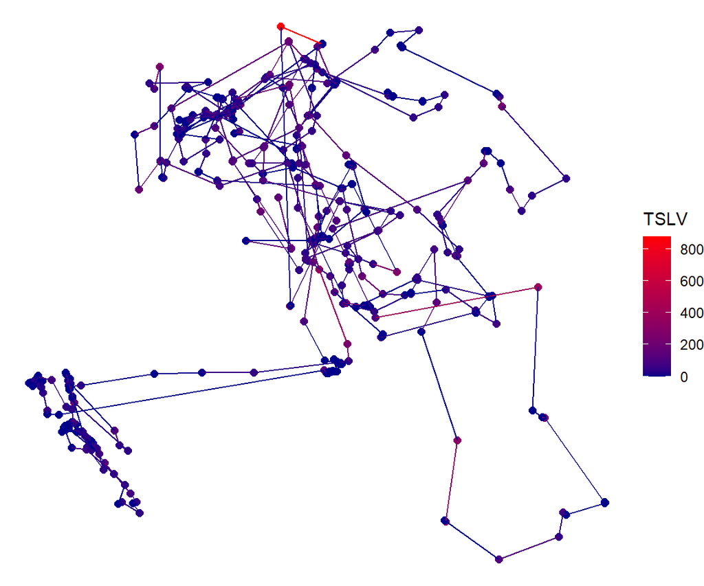

```r
# overall plot - there is a few steps that has really long TSLV values than the others
ssfdat.bear.final %>% filter(step_id_ > 100 & case_==1) %>% ggplot(., aes(x = x1_, y = y1_, col = TSLV))+
  geom_point(size=2)+geom_path() +
  scale_color_gradient2(low = "yellow", mid = "darkblue", high = "red") +
  theme_void()
```

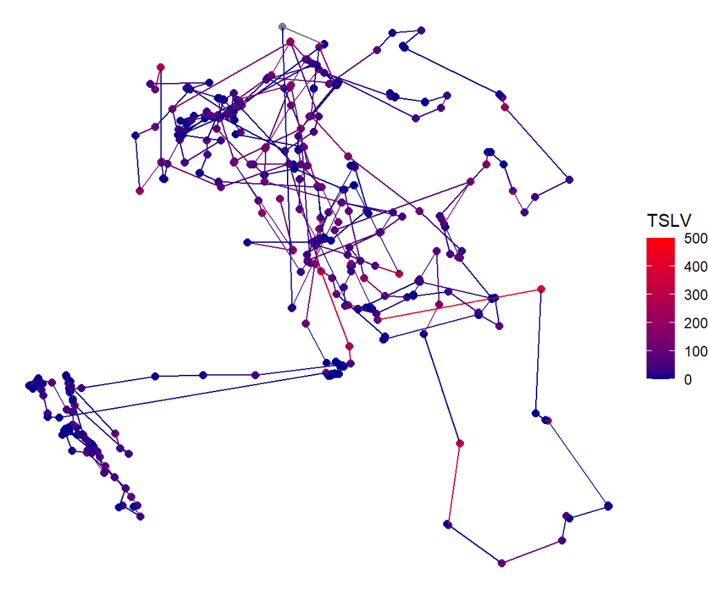

```r
# zoom-in
ssfdat.bear.final %>% filter(step_id_ > 100 & case_==1) %>% ggplot(., aes(x = x1_, y = y1_, col = TSLV))+
  geom_point(size=2)+geom_path() +
  scale_color_gradient2(low = "yellow", mid = "darkblue", high = "red", limits = c(0, 500)) +
  theme_void()
```

## FitSSF

```r
# only resource predictor
ssfdat.bear.final %>% slice(101:n()) %>% amt::fit_issf(case_ ~ berries+ log(sl_)+ cos(ta_)+ strata(step_id_)) %>% summary()
```

```
Call:
coxph(formula = Surv(rep(1, 3646L), case_) ~ berries + log(sl_) +
    cos(ta_) + strata(step_id_), data = data, method = "exact")

  n= 3646, number of events= 434

             coef exp(coef) se(coef)     z Pr(>|z|)
berries  0.007734  1.007764 0.057752 0.134    0.893
log(sl_) 0.044033  1.045017 0.028161 1.564    0.118
cos(ta_) 0.028353  1.028758 0.075645 0.375    0.708

         exp(coef) exp(-coef) lower .95 upper .95
berries      1.008     0.9923    0.8999     1.129
log(sl_)     1.045     0.9569    0.9889     1.104
cos(ta_)     1.029     0.9720    0.8870     1.193

Concordance= 0.528  (se = 0.02 )
Likelihood ratio test= 2.73  on 3 df,   p=0.4
Wald test            = 2.66  on 3 df,   p=0.4
Score (logrank) test = 2.66  on 3 df,   p=0.4
```

```r
# TSLV predictor included
ssfdat.bear.final %>% slice(101:n()) %>% amt::fit_issf(case_ ~ berries+ TSLV+ log(sl_)+ cos(ta_)+ strata(step_id_)) %>% summary()
```

```
Call:
coxph(formula = Surv(rep(1, 3646L), case_) ~ berries + TSLV +
    log(sl_) + cos(ta_) + strata(step_id_), data = data, method = "exact")

  n= 3646, number of events= 434

              coef exp(coef)  se(coef)     z Pr(>|z|)
berries  0.0076011 1.0076301 0.0577457 0.132    0.895
TSLV     0.0002969 1.0002970 0.0009260 0.321    0.748
log(sl_) 0.0417058 1.0425877 0.0290269 1.437    0.151
cos(ta_) 0.0279211 1.0283145 0.0756672 0.369    0.712

         exp(coef) exp(-coef) lower .95 upper .95
berries      1.008     0.9924    0.8998     1.128
TSLV         1.000     0.9997    0.9985     1.002
log(sl_)     1.043     0.9592    0.9849     1.104
cos(ta_)     1.028     0.9725    0.8866     1.193

Concordance= 0.526  (se = 0.02 )
Likelihood ratio test= 2.83  on 4 df,   p=0.6
Wald test            = 2.77  on 4 df,   p=0.6
Score (logrank) test = 2.78  on 4 df,   p=0.6
```

```r
# Interaction between TSLV and berries
ssfdat.bear.final %>% slice(101:n()) %>% amt::fit_issf(case_ ~ berries+ TSLV+ TSLV:berries+ log(sl_)+ cos(ta_)+ strata(step_id_)) %>% summary()
```

```
Call:
coxph(formula = Surv(rep(1, 3646L), case_) ~ berries + TSLV +
    TSLV:berries + log(sl_) + cos(ta_) + strata(step_id_), data = data,
    method = "exact")

  n= 3646, number of events= 434

                   coef  exp(coef)   se(coef)      z Pr(>|z|)
berries      -7.074e-03  9.930e-01  7.495e-02 -0.094    0.925
TSLV         -7.081e-05  9.999e-01  1.519e-03 -0.047    0.963
log(sl_)      4.151e-02  1.042e+00  2.903e-02  1.430    0.153
cos(ta_)      2.709e-02  1.027e+00  7.572e-02  0.358    0.721
berries:TSLV  2.798e-04  1.000e+00  9.072e-04  0.308    0.758

             exp(coef) exp(-coef) lower .95 upper .95
berries         0.9930     1.0071    0.8573     1.150
TSLV            0.9999     1.0001    0.9970     1.003
log(sl_)        1.0424     0.9593    0.9847     1.103
cos(ta_)        1.0275     0.9733    0.8858     1.192
berries:TSLV    1.0003     0.9997    0.9985     1.002

Concordance= 0.517  (se = 0.02 )
Likelihood ratio test= 2.92  on 5 df,   p=0.7
Wald test            = 2.87  on 5 df,   p=0.7
Score (logrank) test = 2.88  on 5 df,   p=0.7
```